# Git_Usage

Tao Zou

2024-04-27

# Upload Files

## Clone to local

Clone the whole project.

```bash
cd path/to/store/clone/files
git clone https://github.com/~/~
```

## Upload to github repository

Move the file I want to upload to the local repository directory.

```bash
cd local/repository/path
git add .
git commit -m 'Add a new file'
git push origin main
```

# Create a git repository

First, create a folder and use `git init`. `pwd` will show the path of folder mytest

```bash
mkdir mytest
cd mytest
pwd
git init
```

Then, create a .txt file, **add** and **commit** the file

```bash
git add readme.txt
git commit -m "create a new file"
```

# Version Tracking

Show the commit history. use `git log` or `git log --pretty=oneline` are both ok.

```bash
git log
```

I can go back to a previous version. *HEAD* is current version, and it can be replaced by *commit_id*. Use `git reflog` to check commit id.

```bash
git reset --hard HEAD
```

# Working directory, Staging area, Master

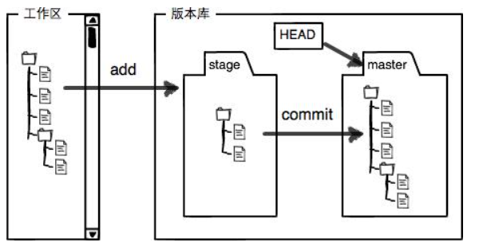

Using `git status` to check working directory and staging directory.

# Withdraw

Withdraw all changed made in working directory by using `git checkout -- file_name`. This command in deed uses file_name in git repository to replace the file in working directory.

Withdraw all changed made in staging directory by using `git restore --staged file_name`, and then using above line to withdraw working directory changes.

# Delete

Delete a file in git repository.

```bash
git rm file_name
git commit -m "delete file file_name"
```

If I use `git rm file_name`, the file will be deleted in working directory and the file’s deleting status will be sent to staging directory. The process keeps the same when I delete a file in Windows Explorer.

# Create a ssh key

Create a ssh key for a computer:

```bash
ssh-keygen -t rsa -C "youremail@example.com"
```

Then open github account setting to add a new ssh key from local user file `.ssh/id_rsa.pub`. After doing this, the computer can push git repository to github repository.

# Link a remote repository

Below shows how to link a github repository through ssh. *origin* is default repository name, and *git@server-name:path/repo-name.git* is repository link.

```bash
git remote add origin git@server-name:path/repo-name.git
```

# Push

Push my local repository at the first time.

```bash
git push -u origin master
```

Push my local repository afterwards.

```bash
git push origin master
```

# Branch

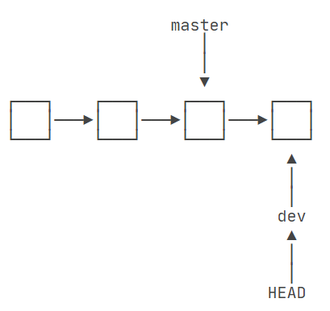

Create a branch named “dev”, and switch to the “dev” branch:

```bash
git checkout -b dev
## git switch -c dev
```

Or I can use `git branch dev` to create a branch and use `git checkout dev` to switch to the branch.

Use `git branch` to show all branches.

Using the code below to merge current branch with the specified branch:

```bash
git merge specified_branch_name
```

Using the code below to delete a branch:

```bash
git branch -d specified_branch_name
```

If I want to delete an unmerged branch, I need to use `-D` instead.

# Conflict

When I try to merge two conflictive branches, the merge process will fail, and turn into the **merging** status. At this status, I can open the conflictive files and correct them. After that, I can use `git add .` and `git commit -m " "` to complete merging.

# Collaboration

When clone from a github repository, I can’t see other branches. I must use `git checkout -b dev origin/dev` to create a branch connecting to the dev branch.

If there is conflict when I push to remote repository, I can use `git pull origin branch_name` to clone and merge locally. After slove the conflict problem locally, I can push the *branch_name* to remote repository.